```
## [1] "Using direct authentication"
```

## ツイッター検索ワード：アクサダイレクト、アクサ損保、アクサ損害保険、アクサ

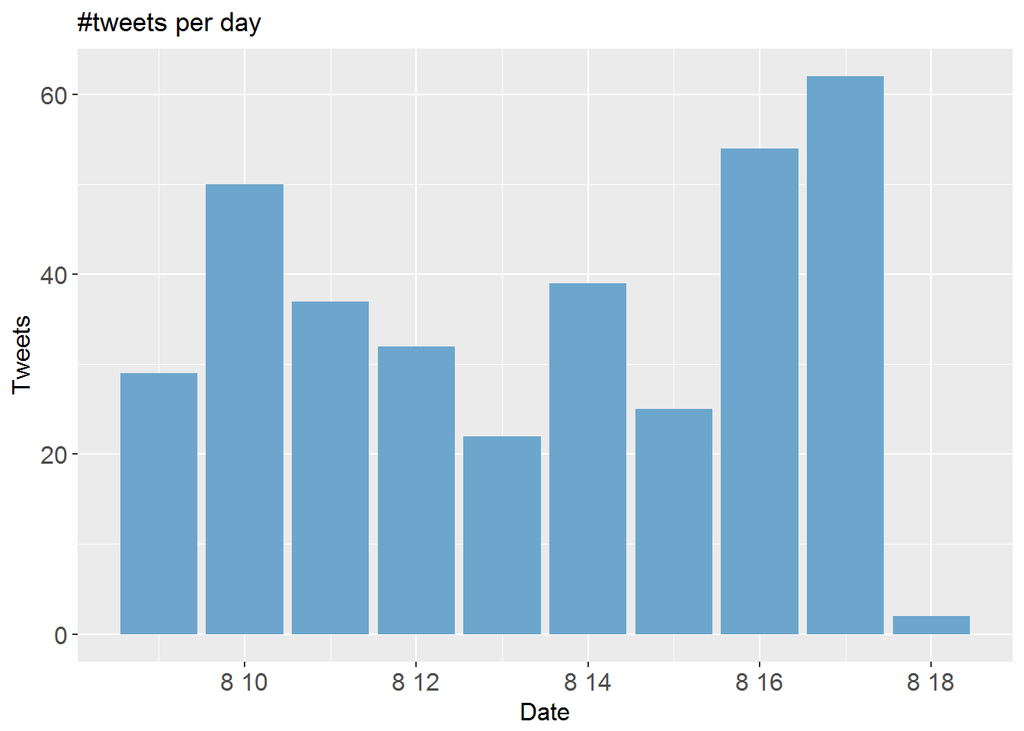

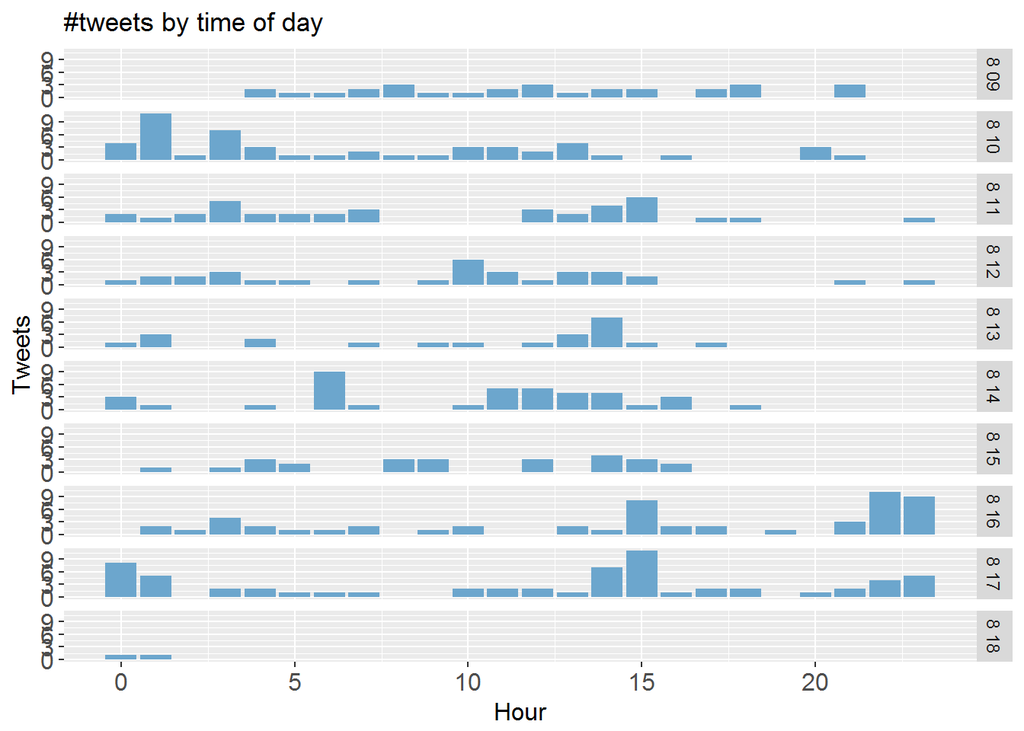

[figure not shown]

## Reply

[figure not shown]

## Retweet

[figure not shown]

| screenName | text | retweetCount |
| --- | --- | --- |
| komei48 | RT @NAMAZUrx: 【悲報】アクサダイレクトのペット保険「いぬのきもち保険、ねこのきもち保険」ペットが病気になり保険を使いだしたら保険使用のお断りをしてくるゴミクソ保険と判明。 https://t.co/skW5S19uHF ペット保険に限らずアクサダイレクトの自動車… | 20203 |
| NOT_CRAZY_ | RT @NAMAZUrx: 【悲報】アクサダイレクトのペット保険「いぬのきもち保険、ねこのきもち保険」ペットが病気になり保険を使いだしたら保険使用のお断りをしてくるゴミクソ保険と判明。 https://t.co/skW5S19uHF ペット保険に限らずアクサダイレクトの自動車… | 20203 |
| onbashira251 | RT @NAMAZUrx: 【悲報】アクサダイレクトのペット保険「いぬのきもち保険、ねこのきもち保険」ペットが病気になり保険を使いだしたら保険使用のお断りをしてくるゴミクソ保険と判明。 https://t.co/skW5S19uHF ペット保険に限らずアクサダイレクトの自動車… | 20203 |
| ichi2222 | RT @NAMAZUrx: 【悲報】アクサダイレクトのペット保険「いぬのきもち保険、ねこのきもち保険」ペットが病気になり保険を使いだしたら保険使用のお断りをしてくるゴミクソ保険と判明。 https://t.co/skW5S19uHF ペット保険に限らずアクサダイレクトの自動車… | 20203 |
| kasuyaakira | RT @NAMAZUrx: 【悲報】アクサダイレクトのペット保険「いぬのきもち保険、ねこのきもち保険」ペットが病気になり保険を使いだしたら保険使用のお断りをしてくるゴミクソ保険と判明。 https://t.co/skW5S19uHF ペット保険に限らずアクサダイレクトの自動車… | 20203 |
| Hawaiian_6_ | RT @NAMAZUrx: 【悲報】アクサダイレクトのペット保険「いぬのきもち保険、ねこのきもち保険」ペットが病気になり保険を使いだしたら保険使用のお断りをしてくるゴミクソ保険と判明。 https://t.co/skW5S19uHF ペット保険に限らずアクサダイレクトの自動車… | 20203 |
| VRRLLLL | RT @NAMAZUrx: 【悲報】アクサダイレクトのペット保険「いぬのきもち保険、ねこのきもち保険」ペットが病気になり保険を使いだしたら保険使用のお断りをしてくるゴミクソ保険と判明。 https://t.co/skW5S19uHF ペット保険に限らずアクサダイレクトの自動車… | 20203 |
| FujIRP | RT @NAMAZUrx: 【悲報】アクサダイレクトのペット保険「いぬのきもち保険、ねこのきもち保険」ペットが病気になり保険を使いだしたら保険使用のお断りをしてくるゴミクソ保険と判明。 https://t.co/skW5S19uHF ペット保険に限らずアクサダイレクトの自動車… | 20203 |
| A_N_Chihuahua | RT @NAMAZUrx: 【悲報】アクサダイレクトのペット保険「いぬのきもち保険、ねこのきもち保険」ペットが病気になり保険を使いだしたら保険使用のお断りをしてくるゴミクソ保険と判明。 https://t.co/skW5S19uHF ペット保険に限らずアクサダイレクトの自動車… | 20203 |
| sumimototakeshi | RT @NAMAZUrx: 【悲報】アクサダイレクトのペット保険「いぬのきもち保険、ねこのきもち保険」ペットが病気になり保険を使いだしたら保険使用のお断りをしてくるゴミクソ保険と判明。 https://t.co/skW5S19uHF ペット保険に限らずアクサダイレクトの自動車… | 20203 |

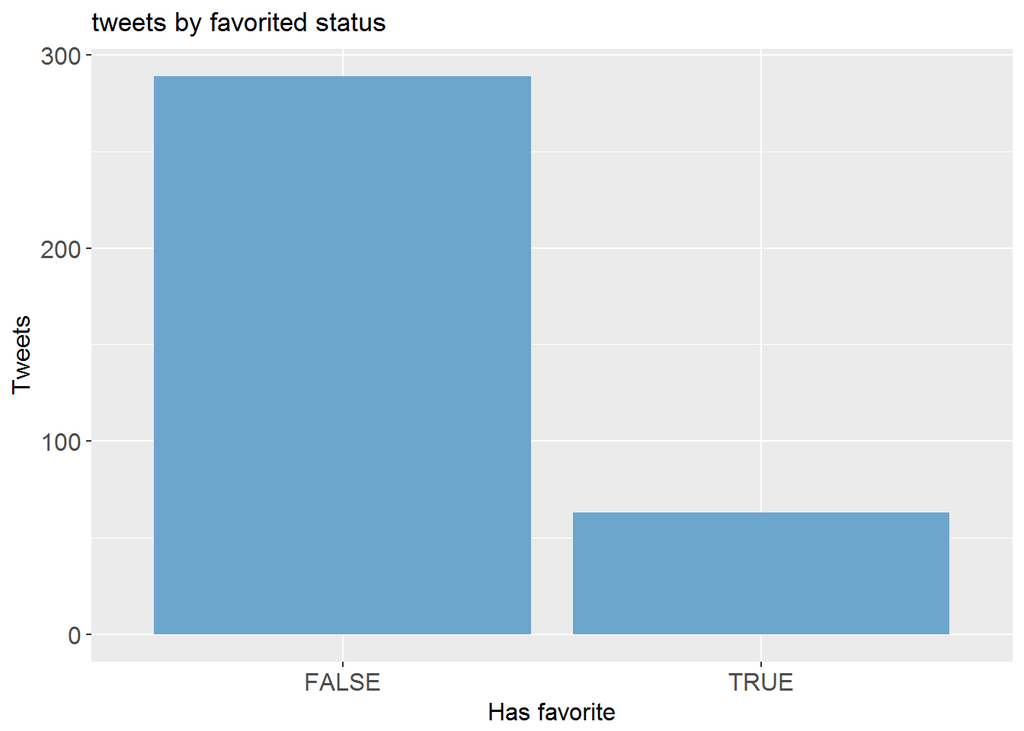

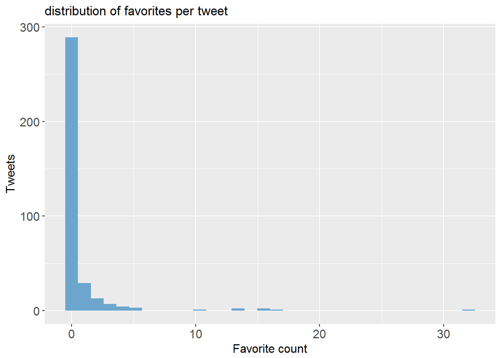

| screenName | text | favoriteCount |
| --- | --- | --- |
| Kelangdbn | 文化系岩瀬D輔の迷走。確率と矛盾した商品を売りつける保険業界は体育会じゃないと通用しない。 ～ ネット保険、赤字で岐路 ライフネットとアクサダイレクト生命 がん保険参入／対面販売を強化 、岩瀬社長が今まで批判してきたがん保険に参入https://t.co/TDt6OAxwBt | 32 |
| AozoraExceed | わーい(о´∀`о) 誕生日のお祝いありがとー♪ アクサダイレクトとBIGLOBEwwwww 毎年のことながらぼっち誕生日だぜ<ed> ¾<ed>´✨ しかも今年は天気まで悪い<ed> ½<ed>¹ 毎年天気だけはよかったんだけどなw 明日朝早いし寝て過ごすか<ed><… | 17 |
| HORIMAI_8 | ハッピーバースデイ ！！<ed> ½<ed>°¥ ひよはとりまおもしろすぎ(笑) 前遊んだのは受験前でなかなかのyamikiでキャバ嬢なろかなとか言うてたけど最近調子はどう ？ 懐かしのアクサダイレクトでも載せといたるやん ッッ 18日楽しみ<ed> ½<ed>¸… https://t… | 15 |
| suda_1229 | 僕の頭だと 18歳だとしてアクサダイレクトでの保険、税金、ガソリン（月100キロだとして）、メンテ代、全部合わせて 月に1万２千円貯めてバイクローン1万で月に2万2千あれば純正の250ccスポバイ維持できる計算になりました。 もう少し高くても車と2台維持出来ちゃうのかもね。 | 15 |
| Syouki8492vivio | アクサなう こっちは雲が凄いな… #アクサダイレクトコーナーはいいぞ https://t.co/a3qqHqFeer | 13 |
| kimryo821 | 良平さんイメージでアクサとか買うなら水色？赤？ いつも赤買っちゃうけどほんとは(？)自由君の色だもんな～ ↓よかったらポチってください | 13 |
| bubu0404 | 岩瀬さんガン保険叩いてたけど参入すふとなwww てか、アクサも赤字だったのね。販売員不要でコスト削減までは良かったけど、その分宣伝広告費がかさんでるのかな？ ネット保険、赤字で岐路：日本経済新聞 https://t.co/Tdi3cyp2Ji | 10 |
| FFgai_bot | スズキから失礼するゾ～（謝罪） アクサダイレクトでスイフト事故りすぎィ！！！！！！自分、涙いいっすか？ 保険料上がりそうだから解約やるぜー いきなり追突すみません！許してください！なんでもしますから！(なんでもするとは言ってない) | 5 |
| kumagoro_bike | MT-03からfz8に乗り換えた保険料の差分はアクサダイレクトの任意保険が800円返却、みんなのバイク保険での盗難・車両保険が解約・新規契約の差分が3万くらい。 来年からの保険料の継続の増分は1.2万くらい。盗難・車両保険は保険対象の車両価格があがった分の値上がりというイメージ。 | 5 |
| minkei | アクサダイレクト生命、高松の百十四銀行にPepper導入 顔認証で保険料試算（高松経済新聞） https://t.co/x08bqYK9fT #みん経 #地域ニュース | 5 |

## 他社ツイート

RT @Kelangdbn: 文化系岩瀬D輔の迷走。確率と矛盾した商品を売りつける保険業界は体育会じゃないと通用しない。 ～ ネット保険、赤字で岐路 ライフネットとアクサダイレクト生命 がん保険参入／対面販売を強化 、岩瀬社長が今まで批判してきたがん保険に参入https://t…

2017-08-18 01:05:46

16

RT @johnlenno0730w: ソニー損保に入ってて良かったわ これもまた、保険料は走る分だけやな https://t.co/f3p0twm436

2017-08-17 19:29:38

1951

RT @misonobucks: 休日の子供は「あのねー、ぼくねー」って100回くらい言うし、喉かわいた・おなか空いた・退屈も50回くらい言うし、「悟空とベジータがねー」も30回くらい言うし、話すネタがなくなったら「東京海上グループの イーデザイン損保♪」ってエンドレスで歌う。

2017-08-13 16:48:36

55

RT @gorinotsukudani: ＳＢＩ証券、少額取引の手数料無料に 若者や初心者獲得：日本経済新聞 https://t.co/eit4DY5KVx １日あたり10万円以下の国内株式の売買について、委託手数料を無料にする。従来は税込みで103円かかっていた。

2017-08-18 01:42:24

94

RT @Keyaki_46Pee: セゾンの1パックがヤバすぎなんだがwwwwww https://t.co/jDOFDpB1JS

2017-08-18 01:17:19

61

RT @ryu_windmusic: おはようございます。 スイス、チューリッヒにて行われたWorld Jugendmusik Festivalのコンサート部門 Topレベルにおいて、総合得点97.50でグランプリを受賞しました！ 沢山の方の応援や支えがあってこそ叶った世界への…

2017-08-17 21:38:24

391

RT @naotaco: 三井住友銀行のSMBCダイレクトはTLS1.0とかいうガバガバ設定だけどゴミカスパズル認証を導入した三井住友Visaカードの方は1.2なんだな。すごい組織の壁があってそれぞれクソみたいな意志決定がなされてるんだな……

2017-08-13 00:18:20

3

RT @Kelangdbn: 文化系岩瀬D輔の迷走。確率と矛盾した商品を売りつける保険業界は体育会じゃないと通用しない。 ～ ネット保険、赤字で岐路 ライフネットとアクサダイレクト生命 がん保険参入／対面販売を強化 、岩瀬社長が今まで批判してきたがん保険に参入https://t…

2017-08-18 00:59:43

16

RT @lgm_asagaolove: ガオラーさんあるある

ソニー損保のCMで過剰反応する

リトグリがカバーしてる曲が流れるとハモっちゃう

ポテトとマクドのCMを見るとアサヒを思い出す。

# リトグリ

# ガオラーさんあるある

#共感した人RT

2017-08-18 01:30:32

44

RT @madstathambot: ステイサム×イーデザイン損保 https://t.co/MZ74eWgFPt

2017-08-16 15:46:03

1

RT @gorinotsukudani: ＳＢＩ証券、少額取引の手数料無料に 若者や初心者獲得：日本経済新聞 https://t.co/eit4DY5KVx １日あたり10万円以下の国内株式の売買について、委託手数料を無料にする。従来は税込みで103円かかっていた。

2017-08-18 01:34:41

94

RT @notekeyaki625: 二人セゾンめっちゃコマ送りで見てたら最初の方から可愛いすぎた

ゆりなぁぁぁぁぁぁ https://t.co/4SEjBC4tNh

2017-08-18 00:45:56

56

RT @tyo21sky: 【報道犯罪】フジテレビ

グッディ@web_goody

捏造報道（30分）https://t.co/tyd1pm704N ⬇ 安倍昭恵夫人を犯罪者扱い ⬇ 訂正（30秒） ⬇ 謝罪無し

スポンサー #不買 ⬇ P&amp;G ジャパネット 再春館製薬所…

2017-08-18 01:55:27

327

RT @naotaco: 三井住友銀行のSMBCダイレクトはTLS1.0とかいうガバガバ設定だけどゴミカスパズル認証を導入した三井住友Visaカードの方は1.2なんだな。すごい組織の壁があってそれぞれクソみたいな意志決定がなされてるんだな……

2017-08-12 16:42:48

3

RT @Kelangdbn: 文化系岩瀬D輔の迷走。確率と矛盾した商品を売りつける保険業界は体育会じゃないと通用しない。 ～ ネット保険、赤字で岐路 ライフネットとアクサダイレクト生命 がん保険参入／対面販売を強化 、岩瀬社長が今まで批判してきたがん保険に参入https://t…

2017-08-17 23:39:54

16

RT @lgm_asagaolove: ガオラーさんあるある

ソニー損保のCMで過剰反応する

リトグリがカバーしてる曲が流れるとハモっちゃう

ポテトとマクドのCMを見るとアサヒを思い出す。

# リトグリ

# ガオラーさんあるある

#共感した人RT

2017-08-17 20:54:04

44

ステイサム×イーデザイン損保 https://t.co/MZ74eWgFPt

2017-08-16 08:10:41

1

RT @wadakooo: ネット証券もどんどんコモディティ化していくので手数料の低下は避けられないですね しかし最大手のSBIがやるとは…！ SBI証券、少額取引の手数料無料に 若者や初心者獲得：日本経済新聞 https://t.co/zxqoJJIU6i

2017-08-18 01:47:33

42

RT @keyakikyowa: 23日の欅共和国でA15ブロックで席が隣で二人セゾンの愛佳の生写真をくれた優しい方を探してます！拡散RTお願いします！ #欅坂 #欅共和国 #長濱ねる #マネパ https://t.co/KJ6UscKNBy

2017-08-18 01:48:03

8

RT @tyo21sky: 【報道犯罪】フジテレビ

グッディ@web_goody

捏造報道（30分）https://t.co/tyd1pm704N ⬇ 安倍昭恵夫人を犯罪者扱い ⬇ 訂正（30秒） ⬇ 謝罪無し

スポンサー #不買 ⬇ P&amp;G ジャパネット 再春館製薬所…

2017-08-18 01:29:35

327

RT @naotaco: 三井住友銀行のSMBCダイレクトはTLS1.0とかいうガバガバ設定だけどゴミカスパズル認証を導入した三井住友Visaカードの方は1.2なんだな。すごい組織の壁があってそれぞれクソみたいな意志決定がなされてるんだな……

2017-08-12 16:40:40

3

RT @Kelangdbn: 文化系岩瀬D輔の迷走。確率と矛盾した商品を売りつける保険業界は体育会じゃないと通用しない。 ～ ネット保険、赤字で岐路 ライフネットとアクサダイレクト生命 がん保険参入／対面販売を強化 、岩瀬社長が今まで批判してきたがん保険に参入https://t…

2017-08-17 21:12:18

16

RT @lgm_asagaolove: ガオラーさんあるある

ソニー損保のCMで過剰反応する

リトグリがカバーしてる曲が流れるとハモっちゃう

ポテトとマクドのCMを見るとアサヒを思い出す。

# リトグリ

# ガオラーさんあるある

#共感した人RT

2017-08-17 20:33:21

44

RT @gragracias: ♪農協改革しようとす～小泉進次郎議員～ #atakowa ♪東京海上グループの～イーデザイン損保～

2017-08-15 07:55:14

1

RT @wadakooo: ネット証券もどんどんコモディティ化していくので手数料の低下は避けられないですね しかし最大手のSBIがやるとは…！ SBI証券、少額取引の手数料無料に 若者や初心者獲得：日本経済新聞 https://t.co/zxqoJJIU6i

2017-08-18 01:46:52

42

RT @Keyakizaka46sbt: 欅坂46『二人セゾン』 2016FNS歌謡祭 ver. https://t.co/ChDqwBL72u

2017-08-18 01:22:15

2

RT @tyo21sky: 【報道犯罪】フジテレビ

グッディ@web_goody

捏造報道（30分）https://t.co/tyd1pm704N ⬇ 安倍昭恵夫人を犯罪者扱い ⬇ 訂正（30秒） ⬇ 謝罪無し

スポンサー #不買 ⬇ P&amp;G ジャパネット 再春館製薬所…

2017-08-18 01:23:12

327

三井住友銀行のSMBCダイレクトはTLS1.0とかいうガバガバ設定だけどゴミカスパズル認証を導入した三井住友Visaカードの方は1.2なんだな。すごい組織の壁があってそれぞれクソみたいな意志決定がなされてるんだな……

2017-08-12 16:26:17

3

RT @Kelangdbn: 文化系岩瀬D輔の迷走。確率と矛盾した商品を売りつける保険業界は体育会じゃないと通用しない。 ～ ネット保険、赤字で岐路 ライフネットとアクサダイレクト生命 がん保険参入／対面販売を強化 、岩瀬社長が今まで批判してきたがん保険に参入https://t…

2017-08-17 21:08:14

16

RT @lgm_asagaolove: ガオラーさんあるある

ソニー損保のCMで過剰反応する

リトグリがカバーしてる曲が流れるとハモっちゃう

ポテトとマクドのCMを見るとアサヒを思い出す。

# リトグリ

# ガオラーさんあるある

#共感した人RT

2017-08-17 18:33:30

44

♪農協改革しようとす～小泉進次郎議員～ #atakowa ♪東京海上グループの～イーデザイン損保～

2017-08-15 00:24:27

1

RT @wadakooo: ネット証券もどんどんコモディティ化していくので手数料の低下は避けられないですね しかし最大手のSBIがやるとは…！ SBI証券、少額取引の手数料無料に 若者や初心者獲得：日本経済新聞 https://t.co/zxqoJJIU6i

2017-08-18 01:37:51

42

RT @ENatsuD46: 欅坂46生写真 希望志田愛佳マネキン初制服より セゾン封入のひき オトシンちゅう 欅宣言 緩く渡辺梨加未所持 検索 サイマジョ封入サイレントマジョリティー衣装ジャケ写シュートサイン通常版渡邉理佐平手友梨奈長濱ねる小林由依今泉佑唯菅井友香長沢菜々香鈴…

2017-08-18 01:22:47

1

RT @tyo21sky: 【報道犯罪】フジテレビ

グッディ@web_goody

捏造報道（30分）https://t.co/tyd1pm704N ⬇ 安倍昭恵夫人を犯罪者扱い ⬇ 訂正（30秒） ⬇ 謝罪無し

スポンサー #不買 ⬇ P&amp;G ジャパネット 再春館製薬所…

2017-08-18 01:22:02

327

三井ダイレクト損保 (08/17) 事故対応コンテンツをリニューアル https://t.co/jFdXTi2Gjt

2017-08-17 15:49:39

2

RT @Kelangdbn: 文化系岩瀬D輔の迷走。確率と矛盾した商品を売りつける保険業界は体育会じゃないと通用しない。 ～ ネット保険、赤字で岐路 ライフネットとアクサダイレクト生命 がん保険参入／対面販売を強化 、岩瀬社長が今まで批判してきたがん保険に参入https://t…

2017-08-17 20:26:58

16

RT @lgm_asagaolove: ガオラーさんあるある

ソニー損保のCMで過剰反応する

リトグリがカバーしてる曲が流れるとハモっちゃう

ポテトとマクドのCMを見るとアサヒを思い出す。

# リトグリ

# ガオラーさんあるある

#共感した人RT

2017-08-17 16:48:19

44

織田裕二といい画面のルックといいほぼ同じなので、イーデザイン損保と佐川急便のCMが全然見分けがつかない。

2017-08-17 16:28:56

0

RT @wadakooo: ネット証券もどんどんコモディティ化していくので手数料の低下は避けられないですね しかし最大手のSBIがやるとは…！ SBI証券、少額取引の手数料無料に 若者や初心者獲得：日本経済新聞 https://t.co/zxqoJJIU6i

2017-08-18 01:36:42

42

欅坂46生写真 希望志田愛佳マネキン初制服より セゾン封入のひき オトシンちゅう 欅宣言 緩く渡辺梨加未所持 検索 サイマジョ封入サイレントマジョリティー衣装ジャケ写シュートサイン通常版渡邉理佐平手友梨奈長濱ねる小林由依今泉佑唯菅… https://t.co/5vejVQl2aD

2017-08-18 01:22:28

1

RT @tyo21sky: 【報道犯罪】フジテレビ

グッディ@web_goody

捏造報道（30分）https://t.co/tyd1pm704N ⬇ 安倍昭恵夫人を犯罪者扱い ⬇ 訂正（30秒） ⬇ 謝罪無し

スポンサー #不買 ⬇ P&amp;G ジャパネット 再春館製薬所…

2017-08-18 01:15:17

327

@masaru_onigiri そうなんですね… 三井ダイレクトはだめでした…

2017-08-18 01:51:01

0

RT @Kelangdbn: 文化系岩瀬D輔の迷走。確率と矛盾した商品を売りつける保険業界は体育会じゃないと通用しない。 ～ ネット保険、赤字で岐路 ライフネットとアクサダイレクト生命 がん保険参入／対面販売を強化 、岩瀬社長が今まで批判してきたがん保険に参入https://t…

2017-08-17 15:41:28

16

RT @lgm_asagaolove: ガオラーさんあるある

ソニー損保のCMで過剰反応する

リトグリがカバーしてる曲が流れるとハモっちゃう

ポテトとマクドのCMを見るとアサヒを思い出す。

# リトグリ

# ガオラーさんあるある

#共感した人RT

2017-08-17 15:33:21

44

イーデザイン損保と佐川のどちらにも出てる織田裕二を使ってなんかつぶやいてる人がいそう

2017-08-17 14:49:02

0

RT @ZARASOKU: ＳＢＩ証券、少額取引の手数料無料に 若者や初心者獲得：日本経済新聞 https://t.co/dRO3bTuHDr

&gt;１日あたり10万円以下の国内株式の売買について、委託手数料を無料にする。従来は税込みで103円かかっていた。

2017-08-18 01:47:03

37

RT @trade_keyza: 提供 欅宣言サイン入り May 平手BC、志田A June 平手A、長濱CD、守屋A、小池B July 小林C U18 志田Z 秘蔵 長濱サイマジョ、小林セゾン

希望 欅坂46直筆関連

dmにて提案お願いします

2017-08-18 01:04:49

1

RT @tyo21sky: 【報道犯罪】フジテレビ

グッディ@web_goody

捏造報道（30分）https://t.co/tyd1pm704N ⬇ 安倍昭恵夫人を犯罪者扱い ⬇ 訂正（30秒） ⬇ 謝罪無し

スポンサー #不買 ⬇ P&amp;G ジャパネット 再春館製薬所…

2017-08-18 01:13:23

327

代理店を通さない保険会社の代表としては以下の保険会社があげられるわ。 ・ソニー損保 ・三井ダイレクト ・そんぽ２４

2017-08-18 01:43:08

0

RT @Kelangdbn: 文化系岩瀬D輔の迷走。確率と矛盾した商品を売りつける保険業界は体育会じゃないと通用しない。 ～ ネット保険、赤字で岐路 ライフネットとアクサダイレクト生命 がん保険参入／対面販売を強化 、岩瀬社長が今まで批判してきたがん保険に参入https://t…

2017-08-17 15:36:19

16

RT @lgm_asagaolove: ガオラーさんあるある

ソニー損保のCMで過剰反応する

リトグリがカバーしてる曲が流れるとハモっちゃう

ポテトとマクドのCMを見るとアサヒを思い出す。

# リトグリ

# ガオラーさんあるある

#共感した人RT

2017-08-17 14:55:54

44

イーデザイン損保 事故解決のプロフェッショナル 「事故現場でもお任せを」篇 (30秒)

#土屋太鳳 https://t.co/kLGcseCp2H

2017-08-17 14:09:52

0

RT @Manojrolan4: @LJodhpur @narendramodi_in Vedo me parman h ki purn sant se nam lene ke bad maryada me rhkr bhkti krne se sbi pap nst krke…

2017-08-18 01:34:33

9

@Poyominami セゾンやクリライだなあとは見れるのですがメンバー見えないです(^_^;)

2017-08-18 01:51:54

0

RT @tyo21sky: 【報道犯罪】フジテレビ

グッディ@web_goody

捏造報道（30分）https://t.co/tyd1pm704N ⬇ 安倍昭恵夫人を犯罪者扱い ⬇ 訂正（30秒） ⬇ 謝罪無し

スポンサー #不買 ⬇ P&amp;G ジャパネット 再春館製薬所…

2017-08-18 01:05:52

327

とりあえず、ビットコインやCASHやVALUEなどの投機性高いフィンテックより、Amazon/ヤフオク/メルカリ/ラクマ、LINEペイ、三井住友ダイレクトなどの身近で使えて確実に儲けれたり、手数料と無駄時間を大幅削減できるフィンテック活用から始めた方が良いと思います。

2017-08-17 21:47:03

0

RT @Kelangdbn: 文化系岩瀬D輔の迷走。確率と矛盾した商品を売りつける保険業界は体育会じゃないと通用しない。 ～ ネット保険、赤字で岐路 ライフネットとアクサダイレクト生命 がん保険参入／対面販売を強化 、岩瀬社長が今まで批判してきたがん保険に参入https://t…

2017-08-17 15:27:35

16

RT @lgm_asagaolove: ガオラーさんあるある

ソニー損保のCMで過剰反応する

リトグリがカバーしてる曲が流れるとハモっちゃう

ポテトとマクドのCMを見るとアサヒを思い出す。

# リトグリ

# ガオラーさんあるある

#共感した人RT

2017-08-17 12:49:30

44

イーデザイン損保のCMの織田裕二と佐川急便のCMの織田裕二、一緒の奴やろ

2017-08-17 13:02:57

0

【#無料 情報】 SBI証券、国内株式委託手数料引き下げのお知らせ～9月4日約定分より、アクティブプラン約定代金合計額10万円以下の手数料を完全無料化～ - PR TIMES (プレスリリース)… https://t.co/bn36olC0bK

2017-08-18 01:55:09

1

@ticheljr ティチさん、おはよう～^ ^金曜日も二人セゾンでがんばろうね<ed> ¼<ed>¾µ

2017-08-18 01:51:24

0

RT @vdgatta: チューリッヒのフラウミュンスター教会。シャガールのステンドグラスがある。また行きたいな～。 https://t.co/90JtyMMNPp

2017-08-18 01:15:04

51

三井ダイレクト損保の自動車保険 https://t.co/reqQUJLQpZ

2017-08-17 21:35:53

0

RT @Kelangdbn: 文化系岩瀬D輔の迷走。確率と矛盾した商品を売りつける保険業界は体育会じゃないと通用しない。 ～ ネット保険、赤字で岐路 ライフネットとアクサダイレクト生命 がん保険参入／対面販売を強化 、岩瀬社長が今まで批判してきたがん保険に参入https://t…

2017-08-17 15:21:09

16

RT @a3copype: ソニー損保CMの女「ヒェ～ッ！ソニーｲｨ損保っﾌｩｰ♪」

丞「！？」

女「保険料は～♪」

丞(保険料はなんなんだ？)

女「ラーラーラー♪」

丞「？」

女「ﾛｰﾄﾞｻｰﾋﾞｽも～♪」

丞(ﾛｰﾄﾞｻｰﾋﾞｽはどうなるんだ？)

女「うーう…

2017-08-18 01:04:12

30

超特急のふじびじスクール！「東京海上グループのイーデザイン損保」の完全版を掲載中です。

(2015/12/12 ふじびじ公式Twitter) https://t.co/kdHZITCotX

2017-08-17 05:29:57

0

ハイパーSBIのGTS4584が買っても歩みが動かね～な～ どうしたかな？

2017-08-18 01:55:51

0

ブログ更新しました。宜しければ御覧下さい。 ならまちセゾン : ８月２５日（金）平成29年 平城山納涼会 in 航空自衛隊奈良基地 https://t.co/X9eGic26On https://t.co/M7paHqng3k

2017-08-18 01:47:43

0

RT @vdgatta: チューリッヒのフラウミュンスター教会。シャガールのステンドグラスがある。また行きたいな～。 https://t.co/90JtyMMNPp

2017-08-18 01:11:40

51

RC8もビートも三井ダイレクトなんだけど、「補償の重複」を自動解消してくれる仕組みにならんかな～と更新のたびに思う。もしくは両方の契約内容を比較しやすい表示とか。

2017-08-17 02:17:39

0

RT @Kelangdbn: 文化系岩瀬D輔の迷走。確率と矛盾した商品を売りつける保険業界は体育会じゃないと通用しない。 ～ ネット保険、赤字で岐路 ライフネットとアクサダイレクト生命 がん保険参入／対面販売を強化 、岩瀬社長が今まで批判してきたがん保険に参入https://t…

2017-08-17 15:19:40

16

RT @rdstrRF: ソニー損保、支払いのクレジットカード変更まで電話での受付で、斬新だった。

2017-08-18 00:49:59

1

イーデザイン損保の曲っぽい

2017-08-17 02:40:19

0

SBI planning IPOs of two regional rural banks in the next one year

2017-08-18 01:54:33

0

@syuma971025tan ダブルコンプしたけどセゾンしてない笑

2017-08-18 01:46:47

0

RT @vdgatta: チューリッヒのフラウミュンスター教会。シャガールのステンドグラスがある。また行きたいな～。 https://t.co/90JtyMMNPp

2017-08-18 00:51:21

51

三井ダイレクト損保が非営利活動法人ＡＳＫ（アスク）に寄付金を贈呈 https://t.co/nH6U3Cp1KC

2017-08-17 01:29:18

0

RT @Kelangdbn: 文化系岩瀬D輔の迷走。確率と矛盾した商品を売りつける保険業界は体育会じゃないと通用しない。 ～ ネット保険、赤字で岐路 ライフネットとアクサダイレクト生命 がん保険参入／対面販売を強化 、岩瀬社長が今まで批判してきたがん保険に参入https://t…

2017-08-17 15:15:24

16

ソニー損保、支払いのクレジットカード変更まで電話での受付で、斬新だった。

2017-08-18 00:49:40

1

今年は自動車保険をダイレクトに変えようかな ソニーかイーデザインか….

2017-08-17 02:11:01

0

SBI planning IPOs of two regional rural banks in the next one year https://t.co/5ZAGEGJ3Li https://t.co/4Yqyhtv5kD

2017-08-18 01:54:25

0

@SIORISIKA__ せかあい2枚とセゾン1枚

2017-08-18 01:43:46

0

RT @vdgatta: チューリッヒのフラウミュンスター教会。シャガールのステンドグラスがある。また行きたいな～。 https://t.co/90JtyMMNPp

2017-08-17 22:54:24

51

代理店を通さない保険会社の代表としては以下の保険会社があげられるわ。 ・ソニー損保 ・三井ダイレクト ・そんぽ２４

2017-08-17 00:43:07

0

RT @Kelangdbn: 文化系岩瀬D輔の迷走。確率と矛盾した商品を売りつける保険業界は体育会じゃないと通用しない。 ～ ネット保険、赤字で岐路 ライフネットとアクサダイレクト生命 がん保険参入／対面販売を強化 、岩瀬社長が今まで批判してきたがん保険に参入https://t…

2017-08-17 15:14:28

16

RT @mame_csk: ソニー損保のCMの女の子唐田えりかはかわいいが声はかわいくない!? https://t.co/9kYpxGznod

2017-08-17 21:43:16

1

@sho0309ii 生命保険ちゃう！自動車保険！！

ソニー、三井ダイレクト、イーデザイン、アクサダイレクトとか

2017-08-17 00:21:35

0

@kaul_vivek pink paper journos and economist care for lower interest rates for industry. I wrote this few weeks ago https://t.co/CQw9c3mJor

2017-08-18 01:52:16

0

@memi__hiragana リプライ有難う御座います。 セゾン封入のチュウは希望しております。 希望はなにでしょうか？？

2017-08-18 01:40:39

0

RT @vdgatta: チューリッヒのフラウミュンスター教会。シャガールのステンドグラスがある。また行きたいな～。 https://t.co/90JtyMMNPp

2017-08-17 22:22:02

51

@sho0309ii 生命保険ちゃう！自動車保険！！

ソニー、三井ダイレクト、イーデザイン、アクサダイレクトとか

2017-08-17 00:21:35

0

RT @Kelangdbn: 文化系岩瀬D輔の迷走。確率と矛盾した商品を売りつける保険業界は体育会じゃないと通用しない。 ～ ネット保険、赤字で岐路 ライフネットとアクサダイレクト生命 がん保険参入／対面販売を強化 、岩瀬社長が今まで批判してきたがん保険に参入https://t…

2017-08-17 15:14:12

16

ソニー損保のCMの女の子唐田えりかはかわいいが声はかわいくない!? https://t.co/9kYpxGznod

2017-08-17 21:00:07

1

【イーデザイン損保】 https://t.co/c5LGZbHqti ★FC東京のクラブスポンサー #fctokyo

2017-08-16 23:13:03

0

自動積立貯金をしようとゆうちょ銀行行ったら投資積立でやるほうがいいと説明を受けた。だったらゆうちょじゃなくてSBIの口座でやるわ～貯金も住信SBIのハイブリッドでいいわ～

2017-08-18 01:50:06

0

次の @YouTube 動画を高く評価しました: https://t.co/o7F08rynTK 【男が歌う】二人セゾン - 欅坂46 Covered by

2017-08-18 01:40:02

0

RT @vdgatta: チューリッヒのフラウミュンスター教会。シャガールのステンドグラスがある。また行きたいな～。 https://t.co/90JtyMMNPp

2017-08-17 21:22:28

51

三井ダイレクト損保のCM、あまりの可愛さに呼吸が乱れた。本当に、死ぬかと思った。ゆるさんぞトオル！娘になりたい

2017-08-16 13:58:02

0

文化系岩瀬D輔の迷走。確率と矛盾した商品を売りつける保険業界は体育会じゃないと通用しない。 ～ ネット保険、赤字で岐路 ライフネットとアクサダイレクト生命 がん保険参入／対面販売を強化 、岩瀬社長が今まで批判してきたがん保険に参入https://t.co/TDt6OAxwBt

2017-08-17 15:12:15

16

RT @125Psyuko: 1(中)えんきん 2(二)日本文化ｾﾝﾀｰ関の職人の包丁 3(右)プロも脱帽する味噌汁 4(一)しじみ習慣 5(三)アフラック癌保険 6(遊)ｺｰﾄﾞﾚｽ草刈り機 刈ってミーナ 7(左)すっぽん皇帝 8(捕)純金積み立て 9(投)ソニー損保

2017-08-17 13:24:46

1

イーデザイン損保 事故解決のプロフェッショナル 「事故現場でもお任せを」篇 (30秒)

#土屋太鳳 https://t.co/kLGcsekOb9

2017-08-16 06:10:11

0

and SBI Begins! “aguy, SAKIT - pose” #SBIAntique2017 #SBIPandan2017 #SBIWesternVisayas2017… https://t.co/rWtvgWmso7

2017-08-18 01:49:46

0

欅の二人セゾンの最高音Hi E♭ってアイドルソングにしては高いな 裏声だけど

2017-08-18 01:36:05

0

RT @vdgatta: チューリッヒのフラウミュンスター教会。シャガールのステンドグラスがある。また行きたいな～。 https://t.co/90JtyMMNPp

2017-08-17 20:40:47

51

三井ダイレクト損保のCMやっぱりかわいい

2017-08-16 12:28:52

0

RT @nikkei_top: [日本経済新聞] ネット専業保険、赤字で岐路 ライフネットやアクサダイレクト (会員限定) https://t.co/xs2uIzLX7Z

2017-08-17 23:13:57

2

代理店を通さない保険会社の代表としては以下の保険会社があげられるわ。 ・ソニー損保 ・三井ダイレクト ・そんぽ２４

2017-08-18 01:43:08

0

イーデザイン損保での車両保険が出てこないことを考えると、NDロードスターの保険率料が上がったのか？ https://t.co/0egOsoXT64

2017-08-15 08:15:36

0

SBI adds Rs 70K cr bad loans with associates’ merger https://t.co/XDiPACNIZF

The merger of five associate banks with State Bank of India …

2017-08-18 01:49:26

0

@NogizakaAsukaxx リプありがとうございます。セゾンというのは今回のセゾンTVでしょうか？

2017-08-18 01:35:25

0

RT @vdgatta: チューリッヒのフラウミュンスター教会。シャガールのステンドグラスがある。また行きたいな～。 https://t.co/90JtyMMNPp

2017-08-17 20:34:58

51

代理店を通さない保険会社の代表としては以下の保険会社があげられるわ。 ・ソニー損保 ・三井ダイレクト ・そんぽ２４

2017-08-15 23:43:09

0

RT @peko409: ネット専業保険、赤字で岐路 ライフネットやアクサダイレクト：日本経済新聞 https://t.co/QI9SysuNsT

2017-08-17 23:09:00

2

私たちの食費をソニー損保さんが調べたそうです！平均は４，８４３円だそうですよ！アナタのおうちはもっと多いですか？少ないですか？お金を掛けてくれるのもうれしいですが、愛情も掛けてくれると、もっと嬉しいです！！

2017-08-18 00:02:31

0

結局、現契約のSBI、全契約のセゾン、前々契約のイーデザインの各サイトでそれぞれ見積もりをかけることになる・・・

2017-08-15 03:26:13

0

あー！iFree から S&amp;P500インデックス出るんじゃん！SBIのiDeCoに追加されないかしら…されるよね……

2017-08-18 01:48:14

0

二人セゾンを歩きながら聴いてると最後のところでペースがはやくなる現象に名前つけたい。

2017-08-18 01:31:45

0

RT @vdgatta: チューリッヒのフラウミュンスター教会。シャガールのステンドグラスがある。また行きたいな～。 https://t.co/90JtyMMNPp

2017-08-17 20:33:53

51

『ムジコロジー・スマイル基金』は寄付先である一般社団法人 moretreesへ寄付金を贈呈しました: MS&amp;ADインシュアランス グループの三井ダイレクト損害保険株式会社（取締役社長：船木… https://t.co/R2XCNmRrPx #特許

2017-08-15 05:27:33

0

RT @sonpo_news: ネット専業保険、赤字で岐路 ライフネットやアクサダイレクト 日本経済新聞 https://t.co/9hUfVPncK9

2017-08-17 17:03:13

2

【線結】次の保険会社とＣＭに出演した女優の正しい組み合わせを選びなさい ソニー損害保険－瀧本美織/損保ジャパン－上戸彩/三井住友海上火災保険－堀北真希/日本興亜損害保険－榮倉奈々 ※女優版その２。覚え方：（堀）北のお堀が火災、ソニーの美（織）しいテレビ

2017-08-17 23:59:04

0

イーデザイン損保 事故解決のプロフェッショナル 「事故現場でもお任せを」篇 (30秒)

#土屋太鳳 https://t.co/kLGcseCp2H

2017-08-14 14:09:52

0

@JuvyAsher @nininSays Ito yung hbang emotional at naiiyak si sg naiiyak din c jlc s gilid.tpos nung sbi ng popsters… https://t.co/fKvGCT4NMN

2017-08-18 01:47:15

0

あっちゃんも欅坂で二人セゾンが一番好きなんだって<ed> ½<ed>¸おそろ❤

2017-08-18 01:27:51

0

RT @nounaionsei: スイスのバーゼル大やチューリッヒ大の研究者・弁護士が、国際学術誌で、「人びとを、思考内容など脳情報の〈窃盗・乱用・ハッキング（theft, abuse and hacking）〉から守る、新たな人権の確立」を提唱した https://t.co/…

2017-08-17 22:56:49

7

代理店を通さない保険会社の代表としては以下の保険会社があげられるわ。 ・ソニー損保 ・三井ダイレクト ・そんぽ２４

2017-08-14 22:43:04

0

RT @sonpo_news: ネット専業保険、赤字で岐路 ライフネットやアクサダイレクト 日本経済新聞 https://t.co/9hUfVPncK9

2017-08-17 16:34:49

2

アフターサービスのいい企業。松井証券、旭化成、ジョーシン、イーアクセス、ソニー損保、ソニー銀行、レスサス、シャープ、ｋ’s電気、パナソニック、ＡＩＵ保険、イトーヨーカドー、ネットスーパー、三井不動産レジデンシャル、リコー・・・どうおもう？

2017-08-17 23:34:08

0

太鳳ちゃんのイーデザイン損保の後に賢人くんのGALAXYのCMやった！ 嬉しい✨

2017-08-14 09:44:29

0

@__sbi__ 료 중고생 때는 어땠어요?! 아 너무 귀여울 것 같다 키는 언제부터 쑥 큰 거예요? 갠적으로 자기보다 키 커져버려서 아유무 첨에 좀 당황했을거같아요 ㅋㅋㅋ 조그만 료는 귀엽고 키 커진 료는 멋잇어요 <ed> ½<ed>¸<ed> ½<ed>¸<ed> ½<ed>¸<ed> ½<ed>¸

2017-08-18 01:45:21

0

1番好きな曲二人セゾンだしアルバムで好きなの猫の名前なんですけど、、、

2017-08-18 01:26:43

0

RT @ponta21: @minajyounouchi @RJinheaven 『TBS社員、危険ドラック金本英哲 51才』

万引きでは実名報道 危険ドラックは名前を隠す

身内に甘い #ひるおび スポンサーの商品は買わない！！ ↓ P&amp;G、キユーピー、meiji 、ミキプ…

2017-08-17 20:25:02

3

@nabeosann 後三井ダイレクト損保？だかのcmで熊のぬいぐるみ使って子供達に説明してるところが可愛い。「専任担当者が君に変わって示談交渉してくれるぞ！」

2017-08-14 12:25:00

0

ネット専業保険、赤字で岐路 ライフネットやアクサダイレクト 日本経済新聞 https://t.co/9hUfVPncK9

2017-08-17 15:29:43

2

ソニー損保の提供でお送りします

2017-08-17 22:34:33

0

@figuremaniacs 最近日テレのCMをご覧いただき、通販型自動車保険のイーデザイン損保を流れますか❓

2017-08-13 21:57:50

0

@shnllurenia Iniisip ko kung papasok eh hahaha pero holiday daw sbi ni chev

2017-08-18 01:45:01

0

@aliqs11 二人セゾンおすすめ

2017-08-18 01:25:12

0

RT @ponta21: @minajyounouchi @RJinheaven 『TBS社員、危険ドラック金本英哲 51才』

万引きでは実名報道 危険ドラックは名前を隠す

身内に甘い #ひるおび スポンサーの商品は買わない！！ ↓ P&amp;G、キユーピー、meiji 、ミキプ…

2017-08-17 19:43:55

3

代理店を通さない保険会社の代表としては以下の保険会社があげられるわ。 ・ソニー損保 ・三井ダイレクト ・そんぽ２４

2017-08-13 21:43:06

0

RT @tsuyochinn7: アクサに連絡だ #けものフレンズ

2017-08-17 22:34:25

1

【速報】 瀧本美織のプロフィールを公開！身長や体重・性格や人気のソニー損保のＣＭまで！バンドの歌や腹筋もお見せします。 https://t.co/yjns2ftLm5

2017-08-17 20:06:05

0

織田裕二のCM出演に一言

佐川急便のCMに出演しながらも イーデザイン損保のCMに出演

佐川急便の車両保険はSGグループ内部の損保なんだけどなぁ… イメージは大丈夫？笑

まぁ…昔の佐川急便は損保に加入してなかったし 働きやすくなったね

# 織田裕二

#佐川急便

2017-08-13 14:28:23

0

ただ 株式数上昇によって持株比率が下がったSBIやオリックスはどうでる？

2017-08-18 01:43:33

0

あとセゾンも 思い出はカレンダーを 思い出は可憐だって思ってた<ed> ½<ed>¸<ed> ½<ed>²

2017-08-18 01:22:45

0

RT @ponta21: @minajyounouchi @RJinheaven 『TBS社員、危険ドラック金本英哲 51才』

万引きでは実名報道 危険ドラックは名前を隠す

身内に甘い #ひるおび スポンサーの商品は買わない！！ ↓ P&amp;G、キユーピー、meiji 、ミキプ…

2017-08-17 19:38:40

3

三井ダイレクト損保はドライバーの運転免許の色（ゴールド、ブルー、グリーン）が保険料金に関係していません。ゴールド免許の人は少し損な感じがするかもしれませんが、ゴールド免許以外の人には大きなメリットですね！

2017-08-13 13:05:55

0

アクサに連絡だ #けものフレンズ

2017-08-17 22:33:52

1

ヒェ～～ソニー損保フゥーーのCM何でこんな腹立つんやろか…

2017-08-17 18:53:57

0

イーデザイン損保 事故解決のプロフェッショナル 「事故現場でもお任せを」篇 (30秒)

#土屋太鳳 https://t.co/kLGcseCp2H

2017-08-13 06:09:44

0

You are requested don’t take any IRCTC SBI Platinum Card to get the Loyalty facilities because no link inbetween SBI &amp; IRCTC except advt.

2017-08-18 01:42:13

0

日本で初めてなんちゃらこんちゃらされたのは1990年の4月29日です 俺｢4月29日か、今年の4月29日は不協和音の全握が京都やってたからおれ行ってたな｣

それでは聞いてください ｢思い出はカレンダー｣（二人セゾン風）

2017-08-18 01:07:16

0

チューリッヒの夜景(スイス) https://t.co/lBKOBnh1ty

2017-08-18 01:29:15

0

バイクの任意保険の見積もりを色んな会社でしてるが三井ダイレクトだけ７万超えとか馬鹿みたいな数字になった

2017-08-13 04:14:50

0

@se_Ciconia しかも台数制限が無いって言う……w 3XVはアクサダイレクトでネット発注www

2017-08-17 23:32:04

0

唐田えりか ソニー損保CM #唐田えりか #ソニー損保 https://t.co/U52YdMPIXU https://t.co/dLueysvMpw

2017-08-17 17:59:21

0

サポートサイト優良企業のトップは自動車保険のイーデザイン損保。3位にSBI損保: トライベック・ブランド戦略研究所は8月9日、企業のサポートを評価する「顧客サポート調査2017」の結果を発表した。… https://t.co/sdeVNhdcRZ #戦略

2017-08-13 04:10:06

0

▶국내 최대의 주식레버리지 스탁론10배 실체결 업체◀ 스탁론 하이스탁론 신용매수자동반대매매 #주식투자기법 스탁론반대매매 #시스템트레이딩 주식자금대출 #주식레버리지 주식스탁론최저비교 sbi스탁론 스탁론이자 주식투자자금대출 골드스탁론 주식대출 #급등주

2017-08-18 01:41:40

0

@koyabu_sakagumi セゾンと不協和音の間にハマったのでまだ行ったことないんです

2017-08-18 01:02:15

0

@Viviann9 @bonnjour @tinamisango ジャルスキーが出ているものだと、こういうのもDVDで出ています♪ご存知かもしれませんが。。 https://t.co/p95TMJUkDx このチューリッヒのアルチ… https://t.co/SjxnATE4ME

2017-08-18 01:04:39

0

三井ダイレクト損保が無能だったから下北沢暴力団員殺害事件が起きてしまった…?

2017-08-13 02:54:59

0

アクサダイレクトからのメールで誕生日と気づきました。なんば近辺で、誕生日にサービスが受けられるお店を探しています。お願いします。 https://t.co/L96ZPIViDw

2017-08-17 23:10:59

0

【定期】 ﾋｨｪｪｪｪｪｪ♪ソニー損保ッ♪(☝ ˘ω˘)☝ふぅー♪

2017-08-17 16:30:22

0

【Ange 岡田茉奈 】 「ヘルシア緑茶」での看護婦役、「東京海上イーデザイン損保」などCM多数出演。「世界・ふしぎ発見！」のミステリーハンターとして今年2回出演。みんな絶対観たことがある美しいお姉さん。水着姿も魅力的！…… https://t.co/nHr7hW06zW

2017-08-13 03:30:07

0

SBIのスピードに楽天はついていって欲しいな。競合いなくなると改悪に転じるだろうから。

2017-08-18 01:39:00

0

保全 (@ ドライブインセゾン in 太田市, 群馬県) https://t.co/QpLRhjdtSn

2017-08-18 00:59:14

0

つぎミラノでテロ起きそうな気してたのにまじかー あと起きてない街どこや… ジュネーヴとチューリッヒは避けるか ヴェネツィアは車通れへんから大丈夫 ローマは元々治安悪いから気にしてない ミラノだけがほんまに怖いな ドゥオーモの前の広場とか特に

2017-08-17 23:53:33

0

三井ダイレクト損保のCMに仲村トオルが！！➳♡゛

2017-08-13 02:23:37

0

ネット専業保険、赤字で岐路 ライフネットやアクサダイレクト：日本経済新聞 https://t.co/ViKTpIeXrZ

2017-08-17 22:46:12

0

ｲｪｪｪｪｪｪｲ 自動車保険の更新なら ソニー損保 ﾌｩｩｩｩｩ 保険料は ﾄｩｯﾄｩｯ ﾗｰﾗｰﾗｰ アクサダイレクトに払った分だけ ロードサービスも ｳｰｳｳｳｰ 有料で付く付く 第1・第3月曜も事故受付 だから選ばれ続… https://t.co/oogVg3bvEP

2017-08-17 14:06:36

0

ステイサム×イーデザイン損保 https://t.co/MZ74eWygH1

2017-08-13 03:10:28

0

SBI is soon planning IPOs of 2 RRBs- Andhra Pradesh Grameena Vikas Bank Saurashtra Gramin Bank

https://t.co/YnlI2F359N

2017-08-18 01:38:57

0

@kk_specialweek これと交換で二人セゾンがないとなると、一番好きなのが二人セゾンだから悩ましい結果でしたw

2017-08-18 00:50:26

0

チューリッヒ市内探検して、平井さんにやっと再会できて、最高に気分が良い。 https://t.co/UEgV3Xz6CN

2017-08-17 23:51:25

0

代理店を通さない保険会社の代表としては以下の保険会社があげられるわ。 ・ソニー損保 ・三井ダイレクト ・そんぽ２４

2017-08-12 20:43:03

0

ネット専業保険、赤字で岐路 ライフネットやアクサダイレクト https://t.co/9S5GLvzI1I

2017-08-17 22:24:42

0

個人的に賀来くんがツボで、美織ちゃんのバカな所がかわいかった。いつソニー損保って言うのかと思ったけど、言わなかった(笑) あとは瀬奈さんの某議員が凄かった。やばい。吉田メタルさんの声好きだわー❤

2017-08-17 13:54:18

0

イーデザイン○ンポ #tvtokyo #udege_gohan https://t.co/nJ6BHCPl0x

2017-08-13 02:39:37

0

and SBI Begins! “Recorders on Post” #SBIAntique2017 #SBIPandan2017 #SBIWesternVisayas2017… https://t.co/4U4YtHcb58

2017-08-18 01:38:28

0

@0625YuRiNa1022 全ツ幕張行く？ セゾンの久美あるで！

2017-08-18 00:46:53

0

【新問】No.0960 2015/11/24 （文パ） チューリッヒに本部を置く国際純正・応用化学連合のアルファベット５文字での略称は○○○○○？→ＩＵＰＡＣ

はいはい水増し

2017-08-17 23:29:00

0

るぅちゃん三井ダイレクト損保のCM見たことある？仲村トオルさんが子供にぬいぐるみもって保険の説明してるんだけど

2017-08-12 11:58:17

0

アクサ(Direct)

2017-08-17 18:33:49

0

ソニー損保の女性が内田有紀に似てると思ったら、本人だった。 40過ぎには見えないねぇ

2017-08-17 13:53:45

0

イーデザイン損保の無事故割引のCMに出てる男の人、仮面ライダーアマゾンズのイユの父親役の人だから、今は安全運転な良き父親かもしれませんがこの後あなたはアマゾンになって娘を…って思っちゃって切なくなる。

2017-08-13 02:07:30

0

@1nRr9LZ8e33OiCX いや前はしてたんよ、松井とツイッター切り替えながらSBIで発注とかw

でもね、久々やろうとしたら手が固まってしまった…

2017-08-18 01:37:11

0

@0625YuRiNa1022 セゾン持ってないな～

2017-08-18 00:44:29

0

CMのチューリッヒ見てると、電話対応職についてる奥様に大人気のイケボアーチャーとかギルガメッシュの会社の受付嬢アーチャーとかとても萌える良き

2017-08-17 23:23:19

0

代理店を通さない保険会社の代表としては以下の保険会社があげられるわ。 ・ソニー損保 ・三井ダイレクト ・そんぽ２４

2017-08-11 19:43:06

0

自動車保険アクサダイレクトの口コミは？ → https://t.co/lD84q7QGzj

2017-08-17 18:28:12

0

ソニー損保、ムカツク！ 絶対使わん！

2017-08-17 12:56:07

0

サポートサイト優良企業のトップは自動車保険のイーデザイン損保。3位にSBI損保 - 保険市場タイムズ

https://t.co/WSwFD0oXCI

2017-08-13 00:45:04

0

SBI証券、国内株式委託手数料引き下げのお知らせ～9月4日約定分より、アクティブプラン約定代金合計額10万円以下の手数料を完全無料化～｜株式会社SBI証券のプレスリリース https://t.co/BNyC06FCJg

2017-08-18 01:36:10

0

熱海の便利屋-大将です。カード決済出来るようになりました。ビザ。マスター。セゾン。ご利用いただけます。高齢者宅の片付け清掃承ります https://t.co/ArSt0CyHmz

2017-08-18 00:43:02

0

オレ様錬金術を ボヘミア学派（化学的） チューリッヒ学派（心理学的 ウィーン学派（性・生理学的） ザルツブルグ学派（医薬学的） に大別してるけど、オレ様の専門はチューリッヒとザルツブルグ。ボヘミアとウィーンは少し話ができる位かな。#錬金術

2017-08-17 22:11:21

0

仲村トオルの三井ダイレクト損保のCMめっちゃかっこいいねんけどどうしよ( ᵒ̴̶̷̤໐ᵒ̴̶̷̤ )

2017-08-11 16:54:59

0

保険・車・携帯あたりが提携して、営業員は自社商品だけでなく3商品全てを、親戚巻き込んで自爆営業しているのはよく観察されるな。

ネット保険、赤字で岐路 ライフネットとアクサダイレクト生命 がん保険参入／対面販売を強化：日本経済新聞 https://t.co/gFLbElPcK2

2017-08-17 17:25:41

0

「任意保険」というのは、つまり、ＣＭで宣伝してたりするやつね。 東京海上保険とかソニー損保とかいろいろあるわね。 消費者側で選択できるものね。 補償範囲も細かく消費者側で選べるはずだわ。 でも、それが、自動車保険は難しいと思われてしまう一番の原因ね。

2017-08-17 12:43:07

0

サポートサイト優良企業のトップは自動車保険のイーデザイン損保。3位にSBI損保 https://t.co/nlcL7wZu4w https://t.co/v0RvNMACIr

2017-08-12 23:32:10

0

@allwaysmaichard parang taped po ata eb ksi sa ig ni ms. telay sbi nya no work today…

2017-08-18 01:33:22

0

二人セゾンのてちが美少女すぎて

2017-08-18 00:43:01

0

@l7_wsk4 うむ。 ウィーンとかからでもいける。 チューリッヒまではミラノから行ったんだけど、バス3000円くらいだった。

2017-08-17 20:25:00

0

三井ダイレクト損保、HDI格付けベンチマークで最高評価の『三つ星』を連続獲得 https://t.co/b2B58vZyFi

2017-08-11 09:01:34

0

アクサと #Ingress がコラボ開始、ゲーム内最強のシールドが登場 https://t.co/bqpw7NqPVm

2017-08-17 15:01:10

0

期待の新星☆彡

唐田えりか 1997年9月19日生まれ 千葉県出身 ソニー損保自動車保険のCMでブレイク中！！ https://t.co/jH5DPq6DgG

2017-08-17 12:26:45

0

【イーデザイン損保】 https://t.co/c5LGZbHqti ★FC東京のクラブスポンサー #fctokyo

2017-08-12 23:13:02

0

भारतीय स्टेट बैंक (SBI) 2014, मुंबई, महाराष्ट्र. विशेषज्ञ संवर्ग अधिकारी पदों की भर्तियां – …

2017-08-18 01:33:22

0

富士急と名古屋の結果～ おとしん3セゾン3紅白3wk11 wkの中のうさみみが可愛すぎて悶絶してる笑 https://t.co/5oAaJIVU5d

2017-08-18 00:42:52

0

car seat ～はチューリッヒキャンセルしてたのか。そういえば予定からチューリッヒが消されてたのに気づかなかったという。

2017-08-17 18:17:49

0

代理店を通さない保険会社の代表としては以下の保険会社があげられるわ。 ・ソニー損保 ・三井ダイレクト ・そんぽ２４

2017-08-10 18:43:04

0